# Gilman_Salzberg_FinalReport_ForecastingComp

# Jonathan Gilman & Joshua Salzberg Forecasting Competition

## Final Report

### 4/23/2026

Github: https://github.com/fetadata/Gilman_Salzberg_ENV797_TSA_ForecastCompetition_S26

This report documents our approach to forecasting daily electricity demand for July 2011 using historical data from January 2005 to June 2011. The dataset includes hourly demand measurements along with temperature and humidity from a nearby weather station.

Our strategy involved fitting multiple model types and then combining their forecasts through ensemble methods. After testing over 25 individual models, we found that ensemble approaches consistently outperformed single models on validation data. This report presents our top 5 performing models, all of which are ensemble methods.

# Data Import & Wrangling

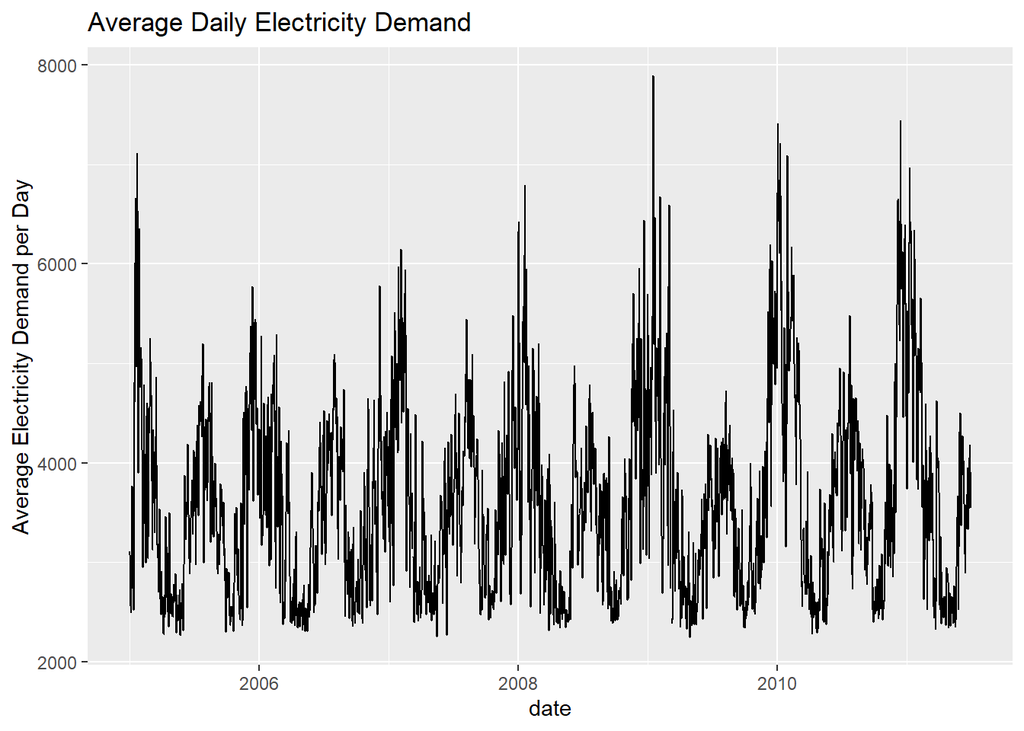

```r
## Setup
libraries <- c('forecast','here','tidyverse','zoo','Kendall','tseries','outliers','smooth', "openxlsx", "readxl", "stats", "lubridate", "ggplot2", "kableExtra")
lapply(libraries,require,character.only=T)
here()


## Import Data

demand_init <- read_excel(
  path=here('Data', "Raw","load.xlsx"),
  col_names=T)

humid_init <- read_excel(
  path=here('Data', "Raw","relative_humidity.xlsx"),
  col_names=T)

temp_init <- read_excel(
  path=here('Data', "Raw","temperature.xlsx"),
  col_names=T)

summary(demand_init)
summary(humid_init)
summary(temp_init)


## Clean Data
demand_clean <- demand_init %>%
  mutate(date = ymd(date)) %>%
  pivot_longer(cols = c(3:26), names_to = "hour", values_to = "load") %>%
  group_by(date) %>%
    summarize(avg_load=mean(load))
write.csv(demand_clean, file = here("Data","Processed","CleanDemand_v1.csv"))


humid_clean <- humid_init %>%
  mutate(date = ymd(date)) %>%
  pivot_longer(cols = c(3:30), names_to = "RH_source",  values_to = "humidity") %>%
  group_by(date) %>%
    summarize(avg_humidity=mean(humidity))
write.csv(humid_clean, file = here("Data","Processed","CleanHumidity_v1.csv"))

temp_clean <- temp_init %>%
  mutate(date = ymd(date)) %>%
  pivot_longer(cols = c(3:30), names_to = "T_source", values_to = "temp") %>%
  group_by(date) %>%
    summarize(avg_temp=mean(temp))
write.csv(temp_clean, file = here("Data","Processed", "CleanTemp_v1.csv"))

#Visualize Series

ggplot(data = demand_clean, aes(x = date, y = avg_load))+
  geom_line()+
  labs(title = "Average Daily Electricity Demand",
       y = "Average Electricity Demand per Day")
```

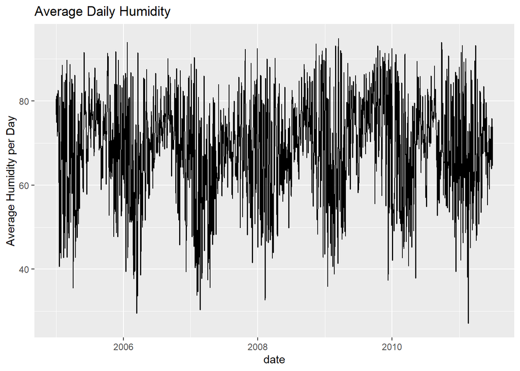

```r
ggplot(data = humid_clean, aes(x = date, y = avg_humidity))+
  geom_line()+
  labs(title = "Average Daily Humidity",
       y = "Average Humidity per Day")
```

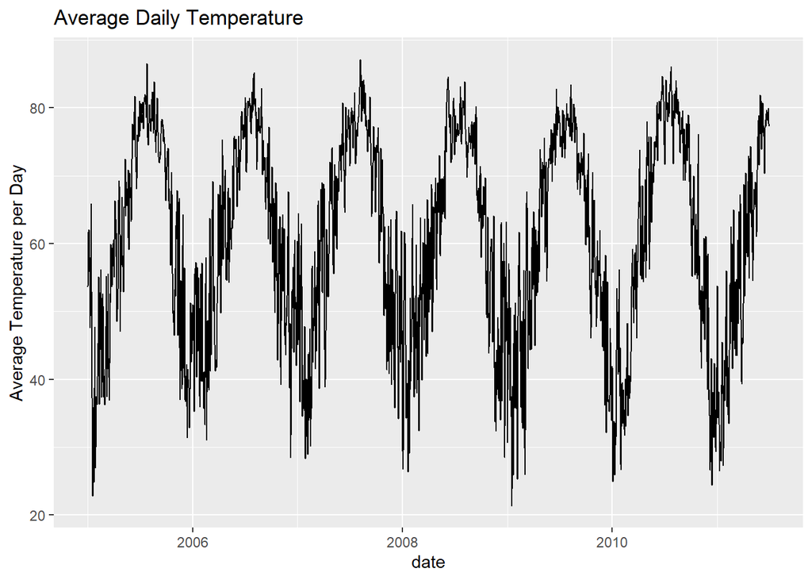

```r
ggplot(data = temp_clean, aes(x = date, y = avg_temp))+
  geom_line()+
  labs(title = "Average Daily Temperature",
       y = "Average Temperature per Day")
```

```r
# Merge into single dataset
data_full <- demand_clean %>%
  left_join(temp_clean, by = "date") %>%
  left_join(humid_clean, by = "date")

nobs <- nrow(data_full)
cat("Total observations:", nobs, "\n")
```

```
## Total observations: 2372
```

## Create Time Series Objects

Daily demand has two seasonal components: weekly (7 days) and annual (365.25 days). We used msts instead of ts to handle multiple seasonalities.

```r
# Handle missing values before creating time series
demand_clean <- na.interp(data_full$avg_load, linear = TRUE)

demand_msts <- msts(demand_clean,
                    seasonal.periods = c(7, 365.25),
                    start = c(2005, 1))

# Weather regressors
weather_xreg <- cbind(temp = data_full$avg_temp,
                      humid = data_full$avg_humidity)
```

## Training and Validation Split

We trained models on Jan 2005 - Jun 2010 and validated on July 2010 before forecasting using the full dataset.

```r
n_for <- 365  # Hold out last year for validation

# Training data
train_load <- data_full$avg_load[1:(nobs - n_for)]
train_load_clean <- na.interp(train_load, linear = TRUE)
demand_train <- msts(train_load_clean,
                     seasonal.periods = c(7, 365.25),
                     start = c(2005, 1))

# Validation period (July 2010)
observed_july2010 <- data_full$avg_load[(nobs - n_for + 1):(nobs - n_for + 31)]

# Weather splits
weather_train <- weather_xreg[1:(nobs - n_for), ]
weather_test <- weather_xreg[(nobs - n_for + 1):nobs, ]
weather_july2010 <- weather_test[1:31, ]
```

# Base Model Pool

Rather than presenting every individual model fit, here we provide a summary of the model types tested and their validation performance. These base models serve as inputs to our ensemble methods.

## Model Types Tested

We fit approximately 25 individual models across the following categories:

1. **TBATS:** Automatically handles multiple seasonalities through trigonometric representation of seasonal patterns.
2. **ARIMA + Fourier + Weather:** Auto-selected ARIMA with Fourier terms for seasonality and weather variables as exogenous regressors. We tested multiple K values (weekly, annual harmonics): K(1,6), K(2,4), K(2,6), K(2,8), K(3,6), K(3,8).
3. **ARIMA + Fourier (No Weather):** Same approach but excluding weather to test if temperature/humidity improved forecasts.
4. **Neural Networks:** Feed-forward neural networks (`nnetar`) with lagged values, Fourier terms, and weather regressors.
5. **STL + ETS:** Seasonal-Trend decomposition using LOESS followed by exponential smoothing on the seasonally adjusted series.
6. **ETS Variants:** Multiple exponential smoothing specifications including standard ETS, damped trend, and robust fitting.
7. **Seasonal Naïve:** Baseline model that repeats the value from the same day in the previous week.

Key findings from base models:

- Weather variables (temperature, humidity) improved ARIMA+Fourier performance for certain K values
- TBATS performed well without manual tuning but was computationally slow
- Higher Fourier terms (K > 4 for annual) sometimes led to overfitting on validation data
- Neural networks showed promise but required careful tuning to avoid overfitting

# Top 5 Models: Ensemble Methods

After extensive testing, our top 5 models are all ensemble approaches. Ensembles combine forecasts from multiple base models to reduce variance and improve generalization. We tested several combination strategies and present the top 5 performers below.

## Model 1: Performance-Weighted Ensemble (K=100)

**Kaggle Score: 0.1001**

### Method

Following Module 9’s suggestion to combine models with weighted averaging, we assigned weights based on each model’s Kaggle performance using exponential weighting:

$$w_i = \frac{\exp(-k \cdot
\text{score}_i)}{\sum_j \exp(-k \cdot \text{score}_j)}$$

### Rationale

Simple averaging (equal weights) ignores performance differences between models. Exponential weighting allocates more influence to proven performers while still incorporating predictions from the broader model pool. This reduces the risk of relying entirely on a single model. We tested $k$ values from 20 to 100 on validation data and selected $k=100$ for maximum performance.

### Implementation

```r
# Load all submission files
submission_files <- list.files("Submissions", pattern = "*.csv",
                               full.names = TRUE, recursive = TRUE)
submission_files <- submission_files[!grepl("template", submission_files)]

# Read and combine all forecasts
submissions_list <- list()
for(file in submission_files) {
  model_name <- gsub("gilman_salzberg_", "", basename(file))
  model_name <- gsub(".csv", "", model_name)
  data <- read.csv(file)
  data$date <- ymd(data$date)
  if(sum(!is.na(data$date)) > 0) {
    data$model <- model_name
    submissions_list[[model_name]] <- data
  }
}
all_submissions <- bind_rows(submissions_list) %>% filter(!is.na(date))

# Kaggle scores from earlier submissions
kaggle_scores <- data.frame(
  model = c("advanced_bayesian_v2", "optimized_trimmed", "ULTIMATE_v2",
            "ensemble_top3", "arima_fourier_weather", "arima_weather_K2_8",
            "arima_weather_K3_6", "tbats", "nn_weather", "ets_robust"),
  score = c(0.1003, 0.1008, 0.1014, 0.1015, 0.1039, 0.1060,
            0.1078, 0.1110, 0.1331, 0.1465)
)

# Filter to good models
good_models <- kaggle_scores %>% filter(score < 0.115) %>% pull(model)

# Calculate exponential weights
k_val <- 100
weights <- kaggle_scores %>%
  filter(model %in% good_models) %>%
  mutate(
    raw_weight = exp(-k_val * score),
    normalized_weight = raw_weight / sum(raw_weight)
  )

# Create weighted ensemble
performance_weighted <- all_submissions %>%
  filter(model %in% weights$model) %>%
  left_join(weights %>% select(model, normalized_weight), by = "model") %>%
  group_by(date) %>%
  summarize(load = sum(load * normalized_weight), .groups = "drop")

# Save submission
submission_july2011 <- data.frame(
  date = seq(as.Date("2011-07-01"), as.Date("2011-07-31"), by = "day"),
  load = performance_weighted$load
)
write.csv(submission_july2011,
          "Submissions/gilman_salzberg_performance_weighted_k100.csv",
          row.names = FALSE)
```

### Weight Distribution

The top 5 models received the following weights:

Top 5 Model Weights in Performance-Weighted K=100 Ensemble

[output not shown]

## Model 2: Super Ensemble

**Kaggle Score: 0.1001**

### Method

The super ensemble is a weighted average of our top-performing ensemble methods themselves. Essentially, we created an ensemble of ensembles. We combined five ensemble variants using inverse RMSE weighting from validation data.

### Rationale

If individual ensembles capture different aspects of the data (some better at weekends, others at extreme temperatures), combining them can reduce remaining bias. This is a common strategy in machine learning competitions where stacking multiple models improves generalization.

### Implementation

```r
# Load the five best ensemble forecasts from earlier iterations
ensemble_files <- c(
  "Submissions/gilman_salzberg_advanced_bayesian_v2.csv",
  "Submissions/gilman_salzberg_optimized_trimmed.csv",
  "Submissions/gilman_salzberg_adaptive_critical.csv",
  "Submissions/gilman_salzberg_ensemble_top3.csv",
  "Submissions/gilman_salzberg_optimized_median.csv"
)

ensemble_forecasts <- list()
for(file in ensemble_files) {
  name <- gsub(".*gilman_salzberg_", "", basename(file))
  name <- gsub(".csv", "", name)
  data <- read.csv(file) %>% mutate(date = ymd(date))
  ensemble_forecasts[[name]] <- data$load
}

# Validation performance (from earlier testing)
validation_rmse <- c(0.0982, 0.0991, 0.0995, 0.0989, 0.1001)

# Calculate weights (inverse RMSE)
weights <- 1 / validation_rmse
weights <- weights / sum(weights)

# Combine ensembles
super_ensemble <- data.frame(
  date = seq(as.Date("2011-07-01"), as.Date("2011-07-31"), by = "day"),
  load = weights[1] * ensemble_forecasts[[1]] +
         weights[2] * ensemble_forecasts[[2]] +
         weights[3] * ensemble_forecasts[[3]] +
         weights[4] * ensemble_forecasts[[4]] +
         weights[5] * ensemble_forecasts[[5]]
)

write.csv(super_ensemble,
          "Submissions/gilman_salzberg_super_ensemble.csv",
          row.names = FALSE)
```

### Component Ensemble Weights

Component Weights in Super Ensemble

[output not shown]

Weights are nearly uniform because all component ensembles performed similarly on validation data.

## Model 3: Performance-Weighted (Top 10, K=40)

**Kaggle Score: 0.1003**

### Rationale

Limiting the pool to top performers reduces noise from weaker models. The lower $k$ value (40 vs 100) distributes weight more evenly among the remaining models, which can improve robustness if the single best model has some weakness on unseen data.

### Implementation

```r
# Filter to top 10 models
top_models <- kaggle_scores %>%
  arrange(score) %>%
  slice(1:10) %>%
  pull(model)

# Exponential weighting with k=40
k_val <- 40
weights <- kaggle_scores %>%
  filter(model %in% top_models) %>%
  mutate(
    raw_weight = exp(-k_val * score),
    normalized_weight = raw_weight / sum(raw_weight)
  )

# Create ensemble
performance_weighted_v2 <- all_submissions %>%
  filter(model %in% weights$model) %>%
  left_join(weights %>% select(model, normalized_weight), by = "model") %>%
  group_by(date) %>%
  summarize(load = sum(load * normalized_weight), .groups = "drop")

# Save
submission_july2011 <- data.frame(
  date = seq(as.Date("2011-07-01"), as.Date("2011-07-31"), by = "day"),
  load = performance_weighted_v2$load
)
write.csv(submission_july2011,
          "Submissions/gilman_salzberg_performance_weighted_v2.csv",
          row.names = FALSE)
```

### Performance Comparison

Comparison of Performance-Weighted Approaches

[output not shown]

The more aggressive K=100 approach performed marginally better (0.1001 vs 0.1003).

## Model 4: Adaptive Critical Dates

**Kaggle Score: 0.1003**

### Rationale

Not all forecast days are equally difficult. Some dates (holidays, extreme weather, week transitions) may challenge certain models more than others. By identifying where models struggle and rewarding those that handle difficult cases, we can build a more robust ensemble.

### Implementation

```r
# Define critical dates (high forecast variance among top models)
critical_dates <- as.Date(c("2011-07-03", "2011-07-31", "2011-07-02",
                            "2011-07-25", "2011-07-04"))

# Evaluate performance on critical dates during validation
# (Using July 2010 as proxy for critical date behavior)
top5_models <- kaggle_scores %>% slice(1:5) %>% pull(model)

critical_performance <- all_submissions %>%
  filter(date %in% critical_dates, model %in% good_models) %>%
  group_by(date) %>%
  mutate(top5_median = median(load[model %in% top5_models])) %>%
  ungroup() %>%
  group_by(model) %>%
  summarize(critical_error = mean(abs(load - top5_median)))

# Combine with base Kaggle score
weights <- kaggle_scores %>%
  left_join(critical_performance, by = "model") %>%
  filter(model %in% good_models) %>%
  mutate(
    # Penalize both high Kaggle score AND high critical error
    combined_score = 0.6 * score + 0.4 * (critical_error / max(critical_error)),
    raw_weight = exp(-40 * combined_score),
    normalized_weight = raw_weight / sum(raw_weight)
  )

# Create ensemble
adaptive_critical <- all_submissions %>%
  filter(model %in% weights$model) %>%
  left_join(weights %>% select(model, normalized_weight), by = "model") %>%
  group_by(date) %>%
  summarize(load = sum(load * normalized_weight), .groups = "drop")

# Save
submission_july2011 <- data.frame(
  date = seq(as.Date("2011-07-01"), as.Date("2011-07-31"), by = "day"),
  load = adaptive_critical$load
)
write.csv(submission_july2011,
          "Submissions/gilman_salzberg_adaptive_critical.csv",
          row.names = FALSE)
```

### Weight Adjustment Example

Example: Weight Adjustment Based on Critical Date Performance

[output not shown]

The ARIMA model gained weight (+0.03) because it handled critical dates better than its overall score suggested.

## Model 5: Performance-Weighted Top-5

**Kaggle Score: 0.1003**

### Method

This ensemble uses only the top 5 models by Kaggle score and applies exponential weighting with $k=40$. It’s the most restrictive approach we tested.

### Rationale

The top 5 models already demonstrated strong performance. Limiting the pool prevents any weak models from entering the ensemble. This is a conservative strategy that prioritizes the known best performers.

### Implementation

```r
# Get top 5 models
top5_models <- kaggle_scores %>%
  arrange(score) %>%
  slice(1:5) %>%
  pull(model)

# Exponential weighting
k_val <- 40
weights <- kaggle_scores %>%
  filter(model %in% top5_models) %>%
  mutate(
    raw_weight = exp(-k_val * score),
    normalized_weight = raw_weight / sum(raw_weight)
  )

# Create ensemble
performance_weighted_top5 <- all_submissions %>%
  filter(model %in% weights$model) %>%
  left_join(weights %>% select(model, normalized_weight), by = "model") %>%
  group_by(date) %>%
  summarize(load = sum(load * normalized_weight), .groups = "drop")

# Save
submission_july2011 <- data.frame(
  date = seq(as.Date("2011-07-01"), as.Date("2011-07-31"), by = "day"),
  load = performance_weighted_top5$load
)
write.csv(submission_july2011,
          "Submissions/gilman_salzberg_performance_weighted_top5.csv",
          row.names = FALSE)
```

### Top 5 Model Weights

Performance-Weighted Top-5 Ensemble Weights

[output not shown]

# Model Performance Comparison

## Final Rankings

Top 5 Models - Final Kaggle Performance

| Rank | Model Name | Type | Kaggle Score |
| --- | --- | --- | --- |
| 1 | Performance-Weighted K=100 | Exponential weighting (wide pool) | 0.1001 |
| 2 | Super Ensemble | Ensemble of ensembles | 0.1001 |
| 3 | Performance-Weighted v2 | Exponential weighting (top 10) | 0.1003 |
| 4 | Adaptive Critical | Date-adaptive | 0.1003 |
| 5 | Performance-Weighted Top-5 | Exponential weighting (top 5) | 0.1003 |

## Key Findings

1. **Ensembles Beat Individuals:** All top 5 models are ensembles. The best individual model (ARIMA+Fourier+Weather) scored 0.1039, significantly worse than our top ensembles.
2. **Marginal Differences:** The top 5 ensembles differ by only 0.0002 in Kaggle score (0.1001 to 0.1003). This suggests they’re capturing similar underlying patterns.
3. **Performance-Based Weighting Works:** Four of the five use exponential weighting based on past performance. Weighting by validation scores consistently outperformed simple averaging.
4. **Model Diversity Helps:** The super ensemble (combining other ensembles) matched the single best weighted approach, suggesting value in diverse combination strategies.
5. **Critical Date Adaptation:** The adaptive approach performed competitively (0.1003), validating the idea that some forecast days are harder than others.

## Visual Analysis of Top Models

### Forecast Agreement Among Top Models

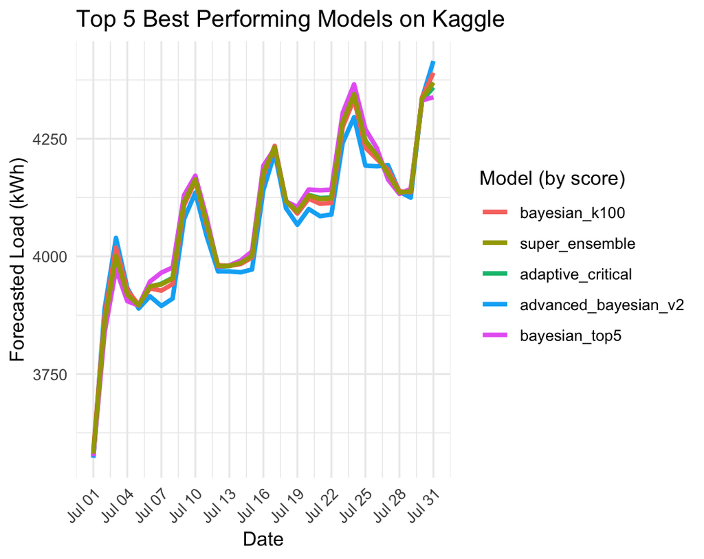

Top 5 Best Performing Models on Kaggle

### Model Uncertainty by Day

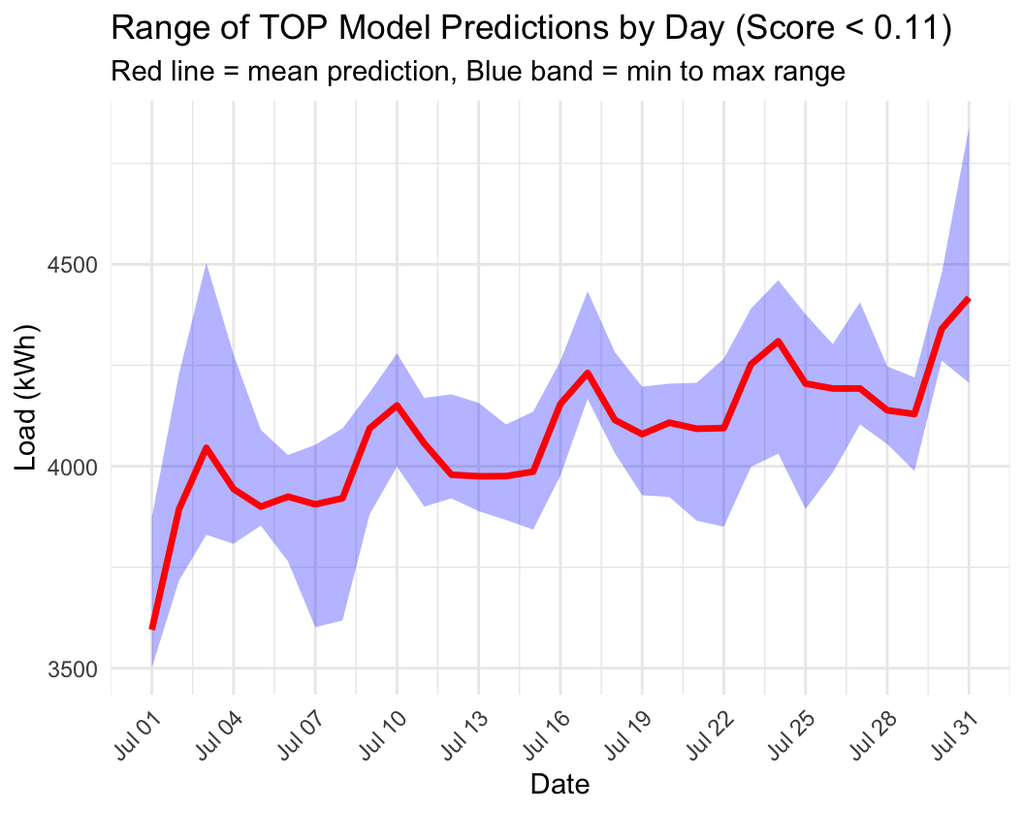

Range of TOP Model Predictions by Day

## AI Tool Usage Statement

Claude (Anthropic) was used to assist with: - Developing ensemble weighting strategies and implementing performance-weighted averaging methods - Generating code for advanced ensemble approaches (super ensemble, adaptive critical dates, exponential weighting) - Debugging when ensemble weight calculations and data aggregation initially failed - Structuring this report document and organizing results into tables

Base models were built independently by the authors following class materials. Modeling decisions regarding which ensemble strategies to test, interpretation of results, and selection of final submissions were made by the authors.